# Statistics 418 HW3

GBM

```r
set.seed(1)
# use r package (without early stop)
library(gbm)
adult_train_gbm <- adult_train1
adult_train_gbm$aw_over_50k <- ifelse(adult_train_gbm$aw_over_50k==1,1,0)
gbm1 <- gbm(aw_over_50k~., data=adult_train_gbm, distribution="bernoulli",n.trees=100,interaction.depth=10,shrinkage=0.01)
yhat_gbm1 <- predict(gbm1, adult_validation1, n.trees=100)
table(ifelse(yhat_gbm1>0,1,0), adult_validation1$aw_over_50k)
```

```
##
##        0    1
##   0 3336  583
##   1   92  515
```

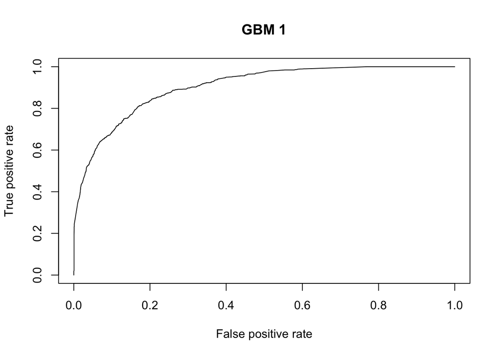

```r
pred_gbm1 <- prediction(yhat_gbm1,adult_validation1$aw_over_50k)
plot(performance(pred_gbm1, "tpr", "fpr"), main="GBM 1")
```

```r
performance(pred_gbm1, "auc")@y.values[[1]]
```

```
## [1] 0.9040277
```

```r
## change parameters
### depth=20, learning rate=0.1
gbm2 <- gbm(aw_over_50k~., data=adult_train_gbm, distribution="bernoulli",n.trees=100,interaction.depth=20,shrinkage=0.1)
yhat_gbm2 <- predict(gbm2, adult_validation1, n.trees=100)
table(ifelse(yhat_gbm2>0,1,0), adult_validation1$aw_over_50k)
```

```
##
##        0    1
##   0 3281  497
##   1  147  601
```

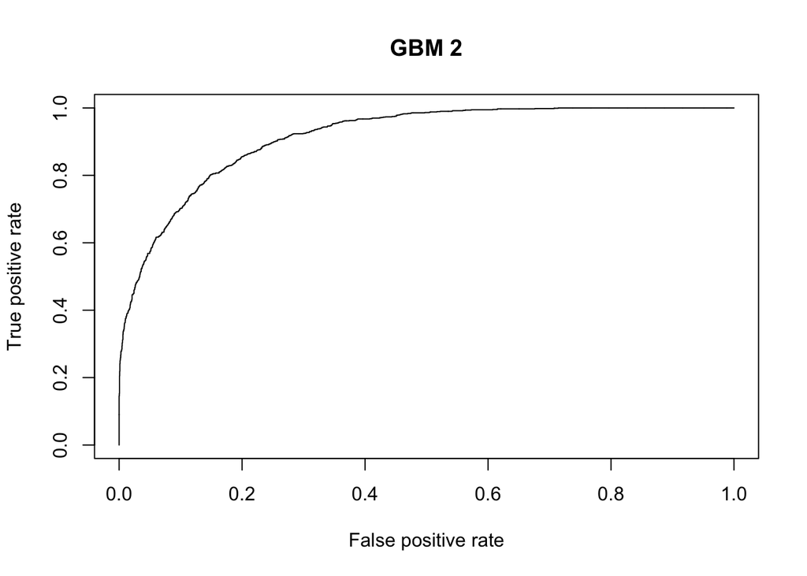

```r
pred_gbm2 <- prediction(yhat_gbm2,adult_validation1$aw_over_50k)
plot(performance(pred_gbm2, "tpr", "fpr"), main="GBM 2")
```

```r
performance(pred_gbm2, "auc")@y.values[[1]]
```

```
## [1] 0.9143806
```

```r
### depth=10, learning rate=0.1
gbm3 <- gbm(aw_over_50k~., data=adult_train_gbm, distribution="bernoulli",n.trees=100,interaction.depth=10,shrinkage=0.1)
yhat_gbm3 <- predict(gbm3, adult_validation1, n.trees=100)
table(ifelse(yhat_gbm3>0,1,0), adult_validation1$aw_over_50k)
```

```
##
##        0    1
##   0 3280  486
##   1  148  612
```

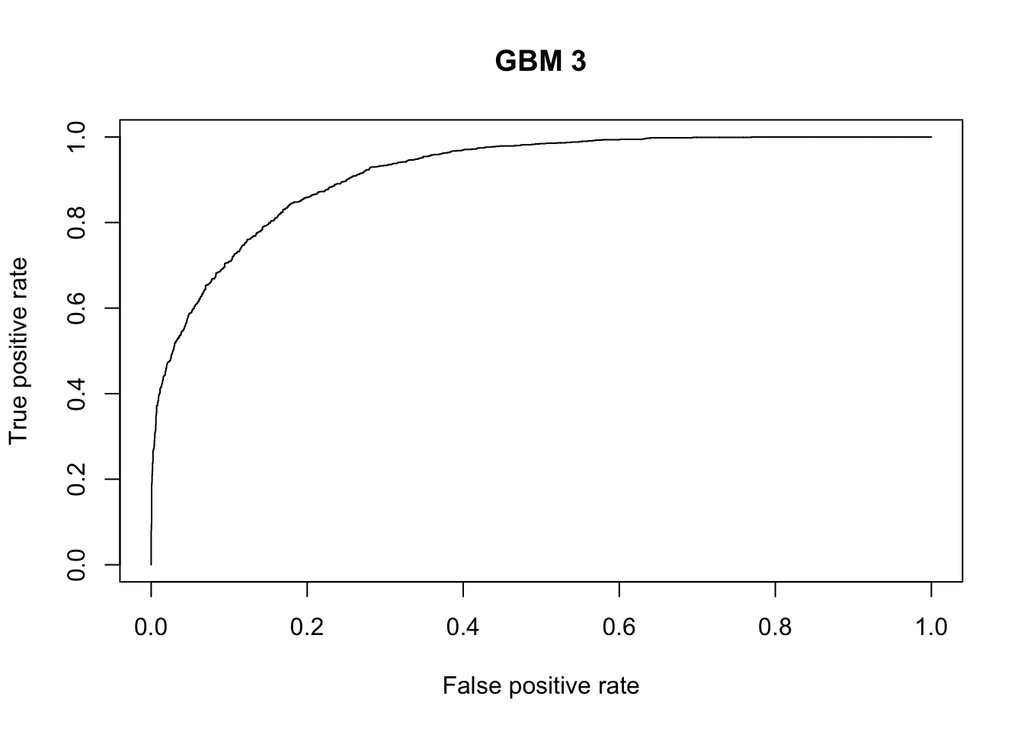

```r
pred_gbm3 <- prediction(yhat_gbm3,adult_validation1$aw_over_50k)
plot(performance(pred_gbm3, "tpr", "fpr"), main="GBM 3")
```

```r
performance(pred_gbm3, "auc")@y.values[[1]]
```

```
## [1] 0.9167741
```

```r
### depth=20, learning rate=0.001
gbm4 <- gbm(aw_over_50k~., data=adult_train_gbm, distribution="bernoulli",n.trees=100,interaction.depth=20,shrinkage=0.001)
yhat_gbm4 <- predict(gbm4, adult_validation1, n.trees=100)
table(ifelse(yhat_gbm4>0,1,0), adult_validation1$aw_over_50k)
```

```
##
##        0    1
##   0 3428 1098
```

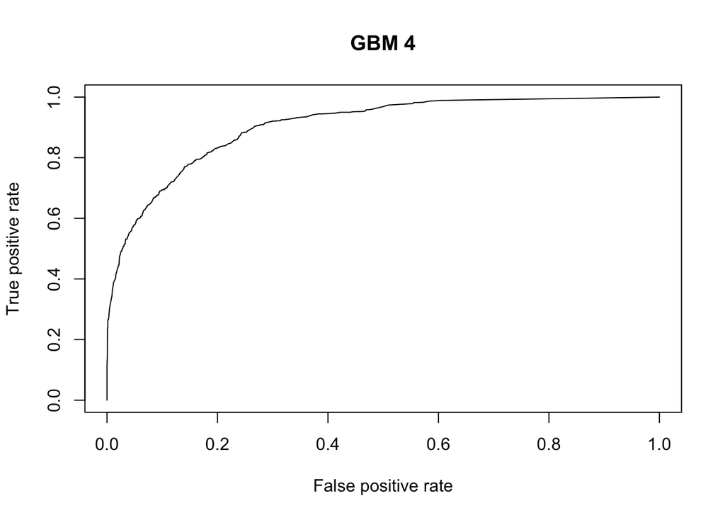

```r
pred_gbm4 <- prediction(yhat_gbm4,adult_validation1$aw_over_50k)
plot(performance(pred_gbm4, "tpr", "fpr"), main="GBM 4")
```

```r
performance(pred_gbm4, "auc")@y.values[[1]]
```

```
## [1] 0.9042539
```

```r
### depth=5, learning rate=0.001
gbm5 <- gbm(aw_over_50k~., data=adult_train_gbm, distribution="bernoulli",n.trees=100,interaction.depth=5,shrinkage=0.001)
yhat_gbm5 <- predict(gbm5, adult_validation1, n.trees=100)
table(ifelse(yhat_gbm5>0,1,0), adult_validation1$aw_over_50k)
```

```
##
##        0    1
##   0 3428 1098
```

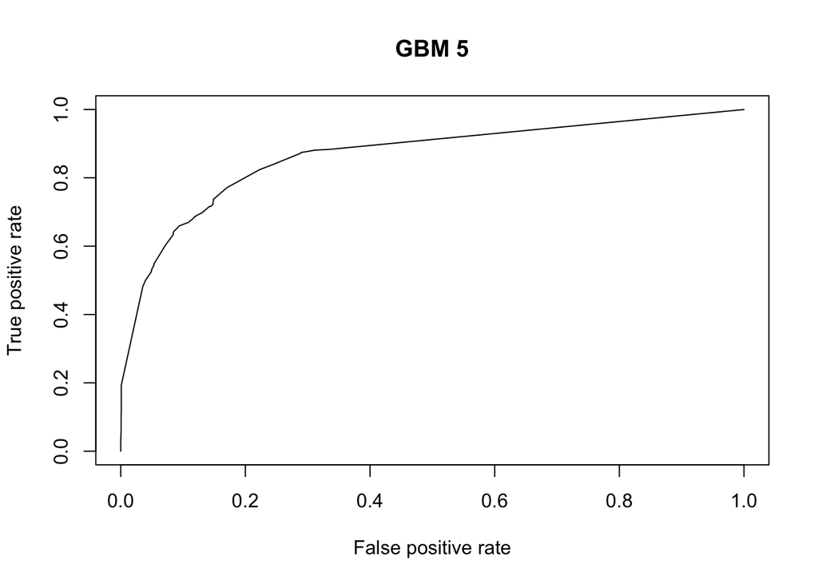

```r
pred_gbm5 <- prediction(yhat_gbm5,adult_validation1$aw_over_50k)
plot(performance(pred_gbm5, "tpr", "fpr"), main="GBM 5")
```

```r
performance(pred_gbm5, "auc")@y.values[[1]]
```

```
## [1] 0.8641205
```

```r
### The best model is gmb3.

## test data
gbm3_test <- gbm(aw_over_50k~., data=adult_train_gbm, distribution="bernoulli",n.trees=100,interaction.depth=10,shrinkage=0.1)
yhat_gbm3_test <- predict(gbm3_test, adult_test1, n.trees=100)
table(ifelse(yhat_gbm3_test>0,1,0), adult_test1$aw_over_50k)
```

```
##
##        0    1
##   0 6714 1564
##   1   54  723
```

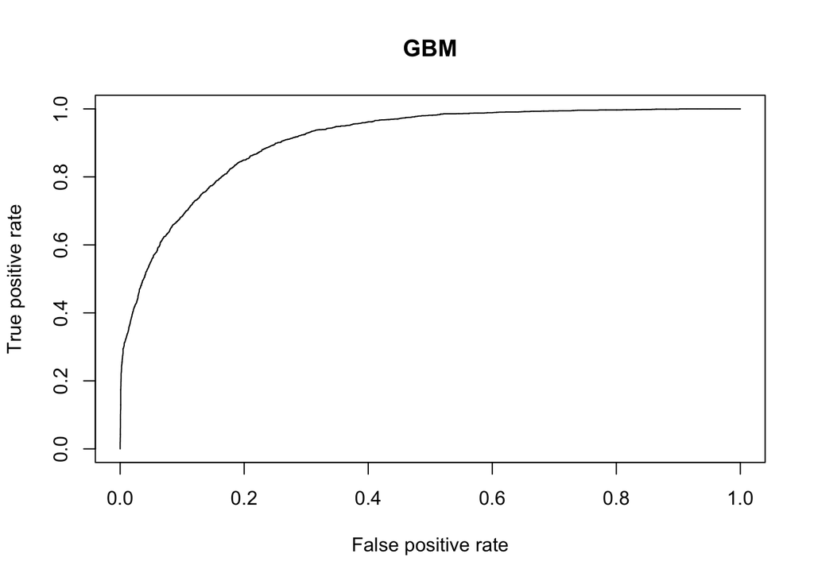

```r
pred_gbm3_test <- prediction(yhat_gbm3_test,adult_test1$aw_over_50k)
plot(performance(pred_gbm3_test, "tpr", "fpr"), main="GBM")
```

```r
performance(pred_gbm3_test, "auc")@y.values[[1]]
```

```
## [1] 0.9080308
```

```r
## FP, TP trade off: when false positive rate is small, true positive rate is also small. If we increase false positive rate, true positive rate will also increase. When false positive rate becomes 0.3, true positive rate can reach around 0.9 and this is a relatively reasonable level.

# use h2o package (with early stop)
adult_gbm_h2o <- h2o.importFile("/Users/apple/Desktop/adult.txt")
colnames(adult_gbm_h2o) <- c("id","age","workclass","final_weight","education","education_num","marital_status","occupation","relationship","race","sex","capital_gain","capital_loss","hours_per_week","natice_country","aw_over_50k")
adult_gbm_h2o <- adult_gbm_h2o[,-1]
adult_gbm_h2o$aw_over_50k <- as.factor(adult_gbm_h2o$aw_over_50k)
adult_gbm_h2o_split <- h2o.splitFrame(adult_gbm_h2o, ratios=c(0.7,0.1))
adult_gbm_h2o_train <- adult_gbm_h2o_split[[1]]
adult_gbm_h2o_validation <- adult_gbm_h2o_split[[2]]
adult_gbm_h2o_test <- adult_gbm_h2o_split[[3]]
adult_gbm_h2o_names <- names(adult_gbm_h2o_train)[which(names(adult_gbm_h2o_train)!="aw_over_50k")]
gbm_h2o <- h2o.gbm(x=adult_gbm_h2o_names, y="aw_over_50k", training_frame=adult_gbm_h2o_train, distribution = "bernoulli", ntrees = 300, max_depth = 20, learn_rate = 0.1,
nbins = 100, stopping_rounds = 5, stopping_tolerance = 1e-4, stopping_metric = "AUC")
h2o.auc(h2o.performance(gbm_h2o, adult_gbm_h2o_validation))
```

```
## [1] 0.9125012
```

```r
## test data
gbm_h2o_test <- h2o.gbm(x=adult_gbm_h2o_names, y="aw_over_50k", training_frame=adult_gbm_h2o_train, distribution = "bernoulli", ntrees = 300, max_depth = 20, learn_rate = 0.1,
nbins = 100, stopping_rounds = 5, stopping_tolerance = 1e-4, stopping_metric = "AUC")
h2o.auc(h2o.performance(gbm_h2o_test, adult_gbm_h2o_test))
```

```
## [1] 0.9129499
```

GBM Result Interpretation: Here I use the GBM algorithm for logistic regression models with different parameters, and get the auc as a criterion to test the goodness of each of model. There are two parameters that vary. One is the learning rate and the other is the depth of the tree. Learning rate, as a regularization parameter, shrinks the comtribution of each new base model, so it is a way to avoid overfitting. Smaller value of learning rate (means more shrinkage) result in less overfitting while larger number of trees tends to cause overfitting. Therefore we hope the shrinkage to be small. Depth of the tree controls the number of splits the tree can have. From the result above, we can tell that the model gbm3 has the largest AUC so that depth of 10 and learning rate of 0.1 are a best combination for the model. Also, for the early stop, it is also to avoid overfitting, in the way that control the number of trees a model can have. Here I use AUC as a metric to determine when to do early stopping.